# CaseStudy2Lull

Ellen Lull

4/18/2020

# MSDS 6306 Case Study 2: Analysis of Employee Data for Attrition and Salary Predictions

## Ellen Lull Section 401

### Read Files and Set up Libraries

.  
Executive Summary This is a DDS Analytics project to predict Attrition and Monthly Income based on data 870 Employee Data Records. This data is to be used to create a model for classifying attrition by significant variables. Next it creates a prediction model for Attrition based on existing variables. It will identify the top three turnover predictors. Then we will create a model to predict monthly income for each of the employees. Predictions on test datasets are output to CSV files for both Attrition and Monthly Income. Finally, we will be looking at three Job roles with high level jobs that have low attrition levels and their employee job satisfaction ratings. This project consists of analysis to cover all of these areas and a video presentation  
[Click Here for Video Presentation](https://www.youtube.com/watch?v=aOa0AA3os3k&feature=youtu.be)

```r
library(tidyverse)
```

```r
library(ggplot2)
library(stringr)
library(dplyr)
library(caret)
library(class)
library(randomForest)
library(glmnet)
library(e1071)
employee <- read.delim("C:/School Stuff/DS/Doing DS/Project2/CaseStudy2-data.csv",header=TRUE,sep=",")

employeenoinc <- read.delim("C:/School Stuff/DS/Doing DS/Project2/CaseStudy2CompSet No Salary.csv",header=TRUE,sep=",")

employeenoatt<- read.delim("C:/School Stuff/DS/Doing DS/Project2/CaseStudy2CompSet No Attrition.csv",header=TRUE,sep=",")
```

### EDA: Run Pairs Plot for Continuous Variables

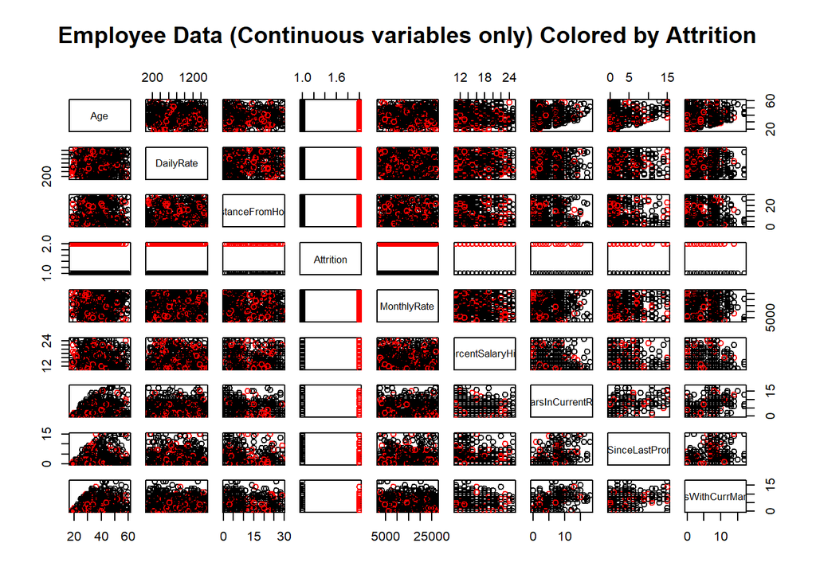

```r
employee_reduced = employee[,c('Age','DailyRate','DistanceFromHome','Attrition','MonthlyRate','PercentSalaryHike','YearsInCurrentRole','YearsSinceLastPromotion','YearsWithCurrManager')]

pairs(employee_reduced,col=employee$Attrition,main='Employee Data (Continuous variables only) Colored by Attrition')
```

Plot Every Variable as Related to Attrition and Monthly Income ### EDA: Plot Relationships related to Attrition and Monthly Income for all 36 Variables

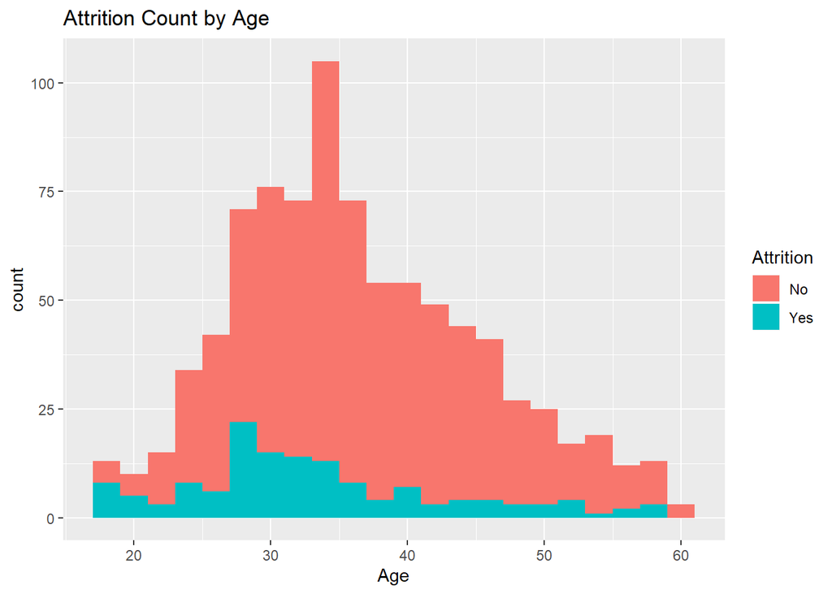

```r
employee %>% ggplot(aes(x = Age,fill=Attrition)) + geom_histogram(binwidth=2) + ggtitle("Attrition Count by Age") +
xlab ("Age")
```

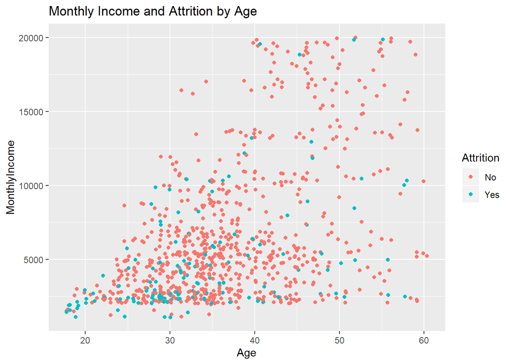

```r
employee %>% ggplot(aes(x = Age,y=MonthlyIncome,col=Attrition)) + geom_point(pos='Jitter') + ggtitle("Monthly Income and Attrition by Age") +
    xlab ("Age")
```

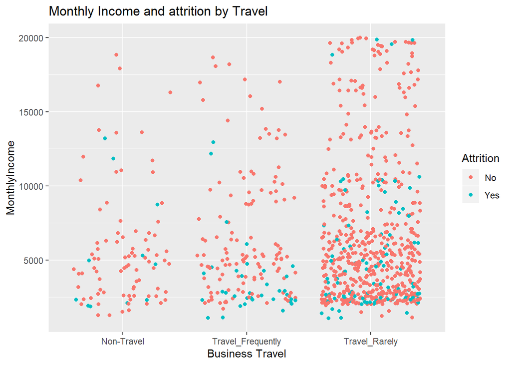

```r
employee %>% ggplot(aes(x = BusinessTravel,y=MonthlyIncome,col=Attrition)) + geom_point(pos='Jitter') + ggtitle("Monthly Income and attrition by Travel") +
    xlab ("Business Travel")
```

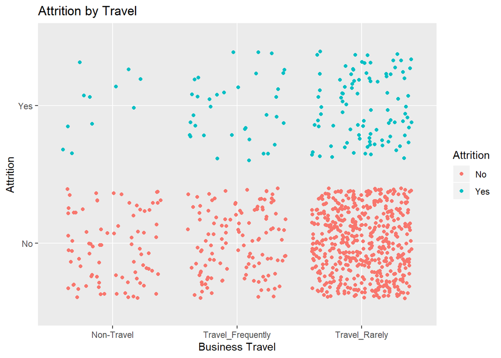

```r
employee %>% ggplot(aes(x = BusinessTravel,y=Attrition,col=Attrition)) + geom_point(pos='Jitter') + ggtitle("Attrition by Travel") +
xlab ("Business Travel")
```

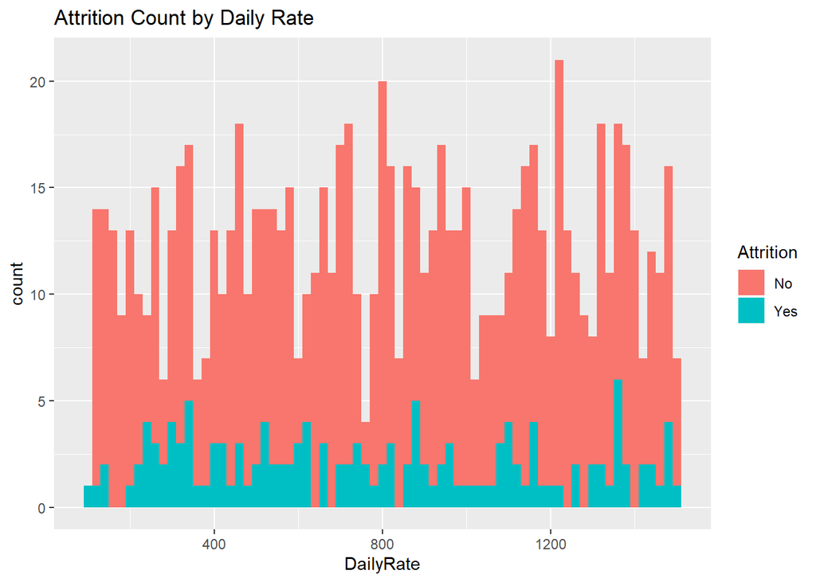

```r
###  Continous: DailyRate
employee %>% ggplot(aes(x = DailyRate,fill=Attrition)) + geom_histogram(binwidth=20) + ggtitle("Attrition Count by Daily Rate")
```

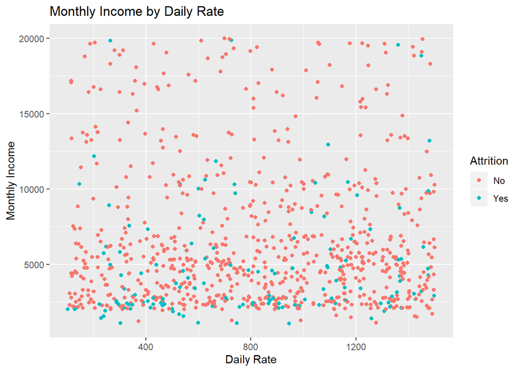

```r
###  Continous: DailyRate

employee %>% ggplot(aes(x = DailyRate,y=MonthlyIncome,col=Attrition)) + geom_point(pos='Jitter') + ggtitle("Monthly Income by Daily Rate") +
xlab ("Daily Rate") +
ylab ("Monthly Income")
```

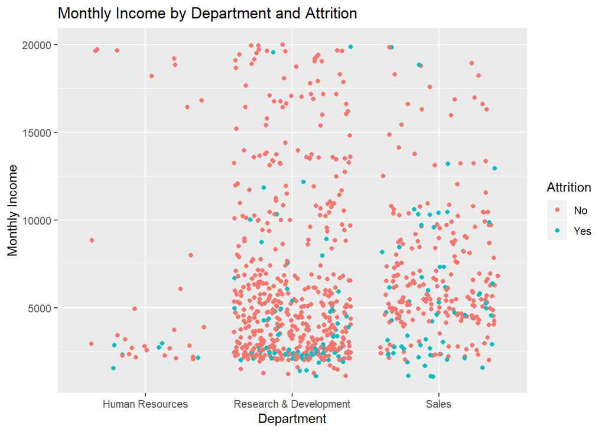

```r
### Categorical: Department
employee %>% ggplot(aes(x = Department,y=MonthlyIncome,col=Attrition)) + geom_point(pos='Jitter') + ggtitle("Monthly Income by Department and Attrition") +
xlab ("Department") +
ylab ("Monthly Income")
```

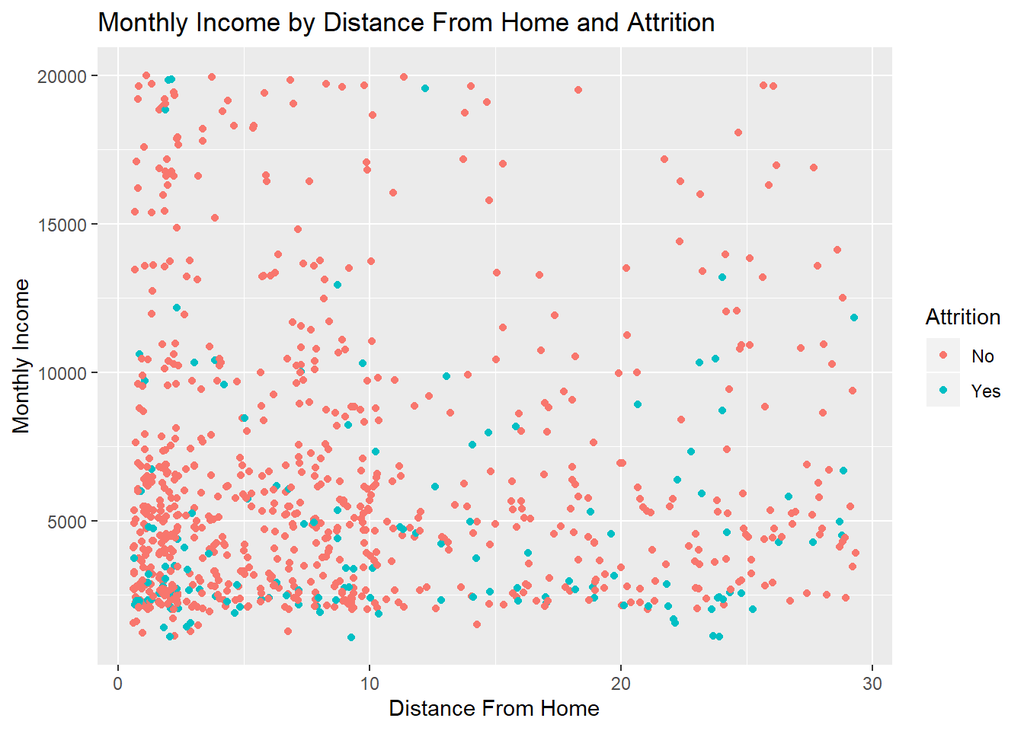

```r
### Continuous: DistanceFromHome
employee %>% ggplot(aes(x = DistanceFromHome,y=MonthlyIncome,col=Attrition)) + geom_point(pos='Jitter') + ggtitle("Monthly Income by Distance From Home and Attrition") +
xlab ("Distance From Home") +
ylab ("Monthly Income")
```

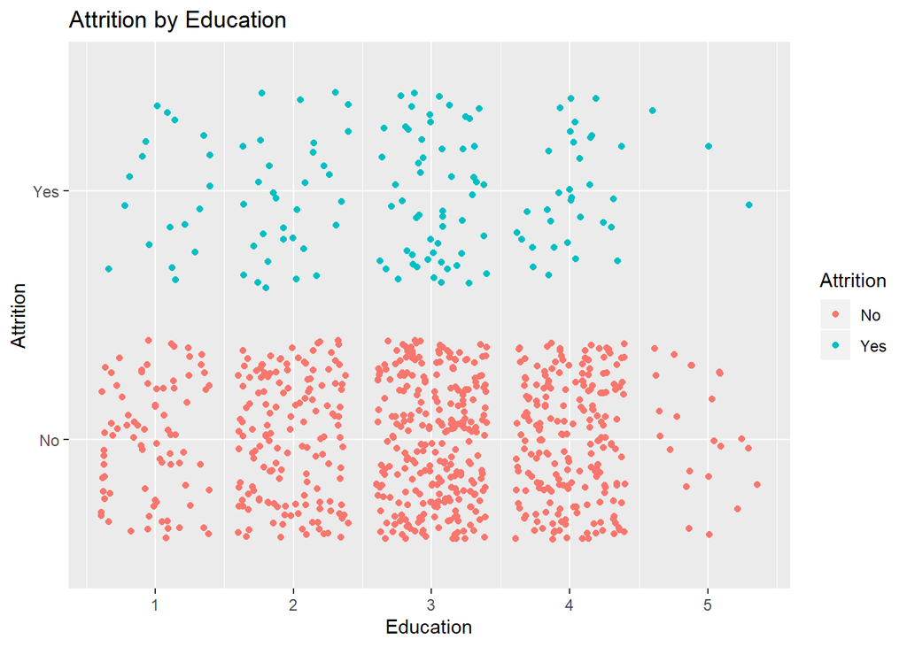

```r
### Categorical: Education
### Look at further to see < 4 years versus 4/5 years
employee %>% ggplot(aes(x = Education,y=Attrition,col=Attrition)) + geom_point(pos='Jitter') + ggtitle("Attrition by Education")
```

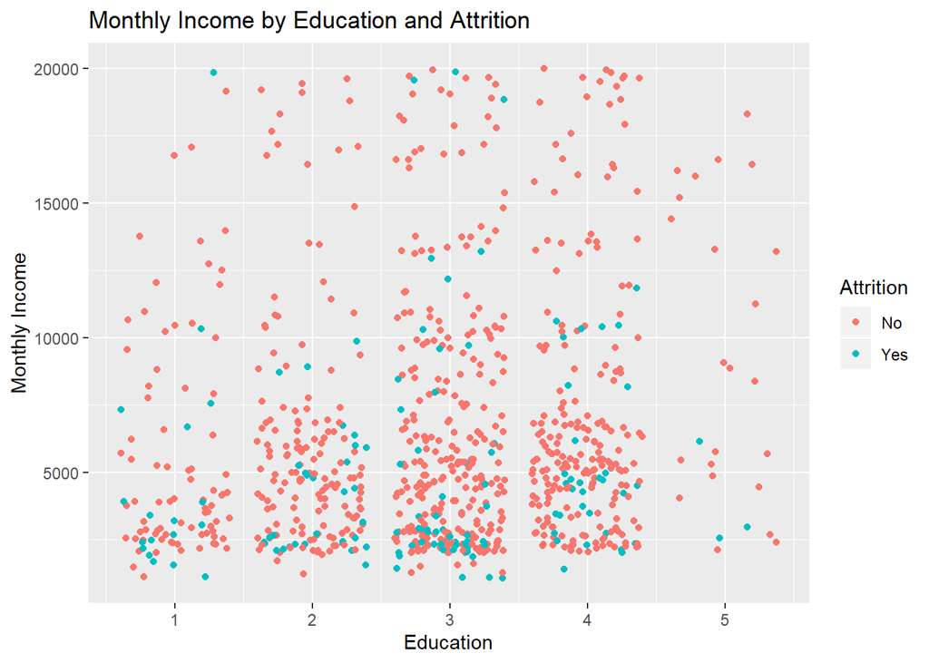

```r
employee %>% ggplot(aes(x = Education,y=MonthlyIncome,col=Attrition)) + geom_point(pos='Jitter') + ggtitle("Monthly Income by Education and Attrition") +
xlab ("Education") +
ylab ("Monthly Income")
```

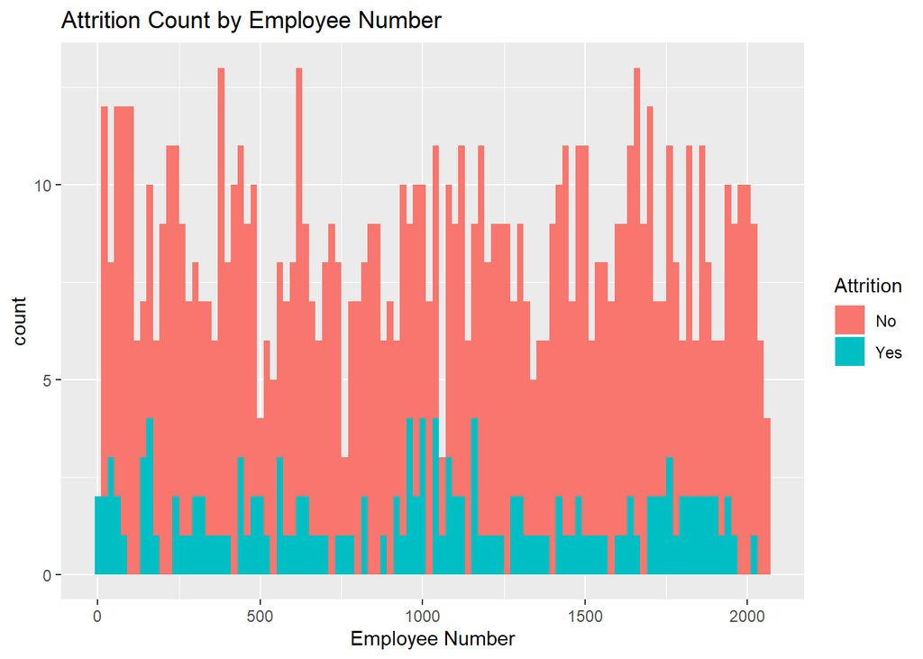

```r
### Employee Count is always 1

### Continuous: EmployeeNumber

employee %>% ggplot(aes(x = EmployeeNumber,fill=Attrition)) + geom_histogram(binwidth=20) + ggtitle("Attrition Count by Employee Number") +
xlab ("Employee Number")
```

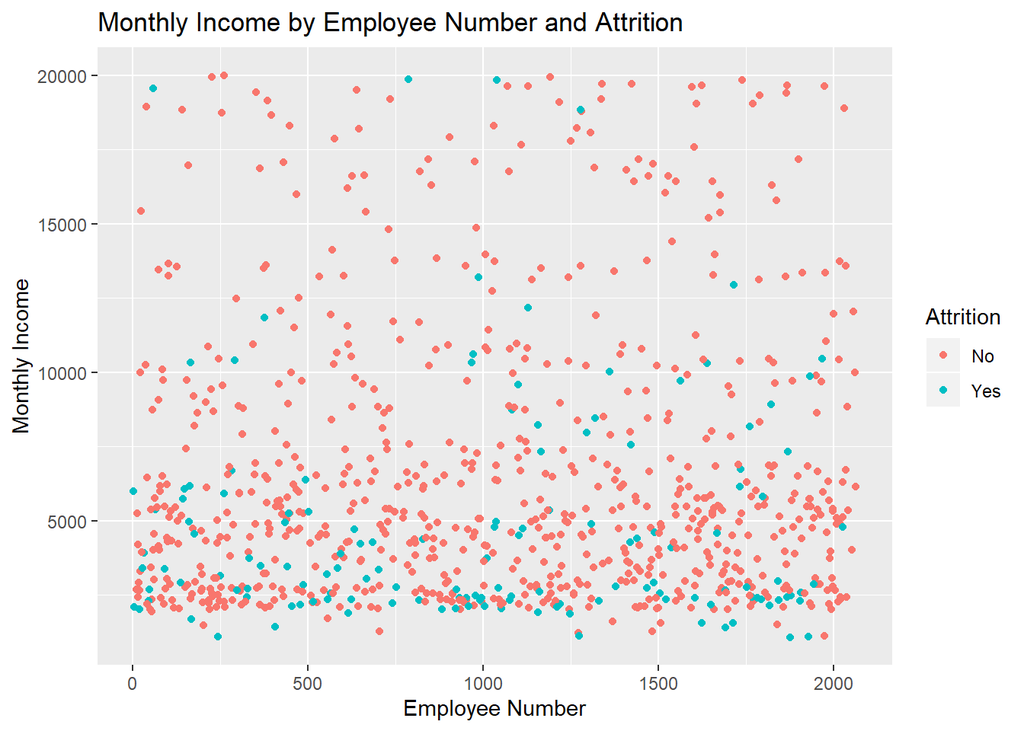

```r
employee %>% ggplot(aes(x = EmployeeNumber,y=MonthlyIncome,col=Attrition)) + geom_point(pos='Jitter') + ggtitle("Monthly Income by Employee Number and Attrition") +
xlab ("Employee Number") +
ylab ("Monthly Income")
```

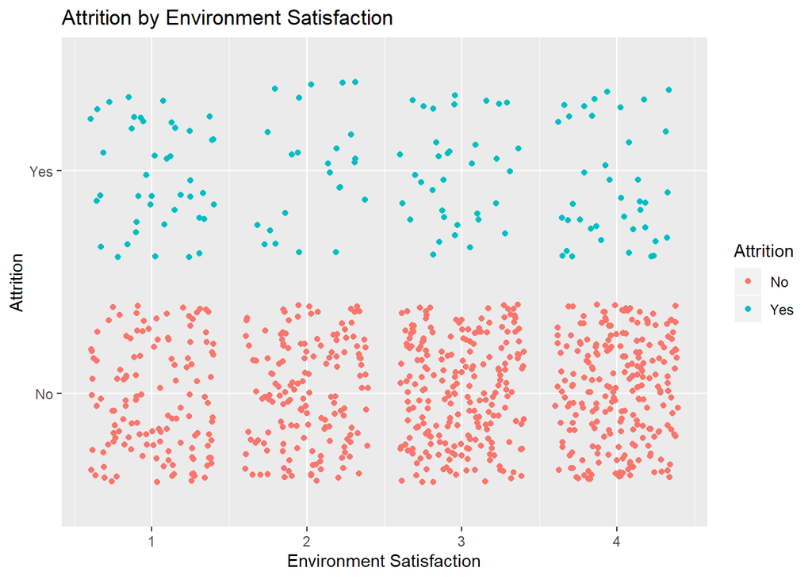

```r
### Categorical: EnvironmentSatisfaction
employee %>% ggplot(aes(x = EnvironmentSatisfaction,y=Attrition,col=Attrition)) + geom_point(pos='Jitter') + ggtitle("Attrition by Environment Satisfaction") +
xlab ("Environment Satisfaction")
```

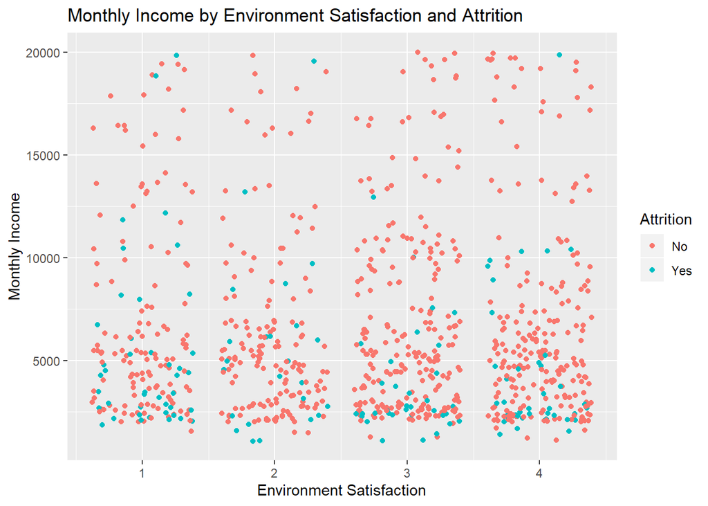

```r
employee %>% ggplot(aes(x = EnvironmentSatisfaction,y=MonthlyIncome,col=Attrition)) + geom_point(pos='Jitter') + ggtitle("Monthly Income by Environment Satisfaction and Attrition") +
xlab ("Environment Satisfaction") +
ylab ("Monthly Income")
```

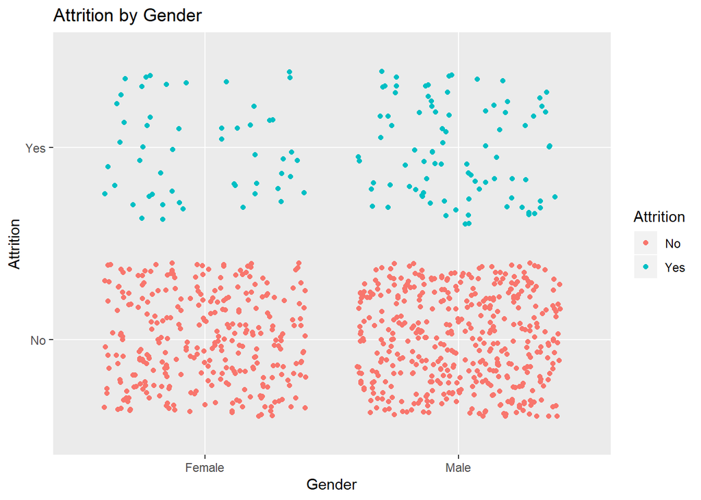

```r
### Categorical: Gender
### Males have a higher rate

employee %>% ggplot(aes(x = Gender,y=Attrition,col=Attrition)) + geom_point(pos='Jitter') + ggtitle("Attrition by Gender")
```

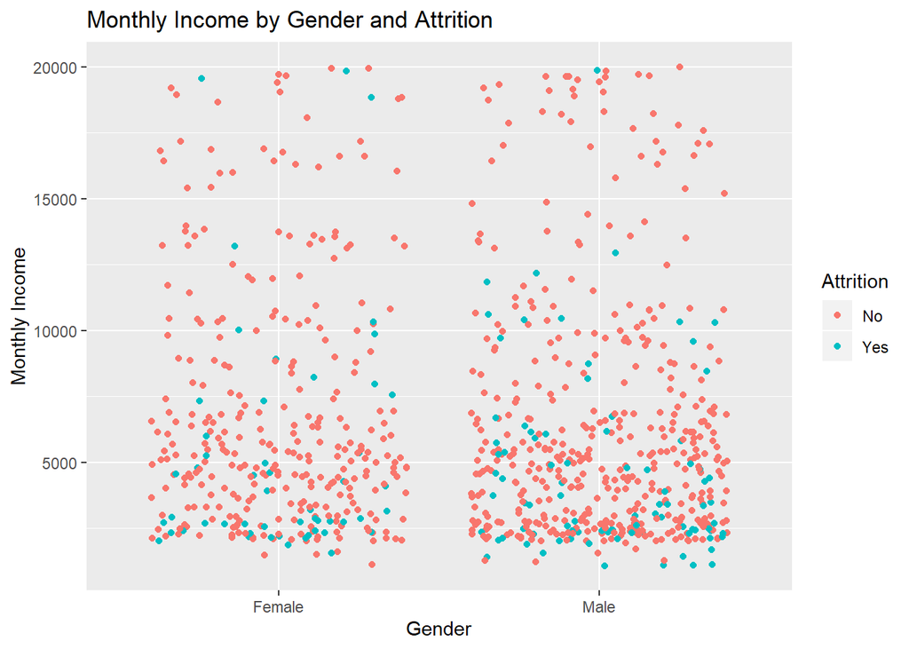

```r
employee %>% ggplot(aes(x = Gender,y=MonthlyIncome,col=Attrition)) + geom_point(pos='Jitter') + ggtitle("Monthly Income by Gender and Attrition") +
xlab ("Gender") +
ylab ("Monthly Income")
```

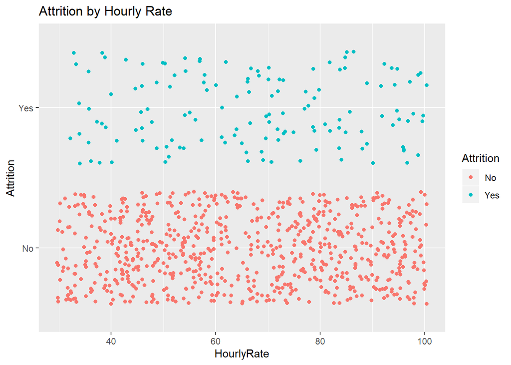

```r
### Continuous: HourlyRate

employee %>% ggplot(aes(x = HourlyRate,y=Attrition,col=Attrition)) + geom_point(pos='Jitter') + ggtitle("Attrition by Hourly Rate")
```

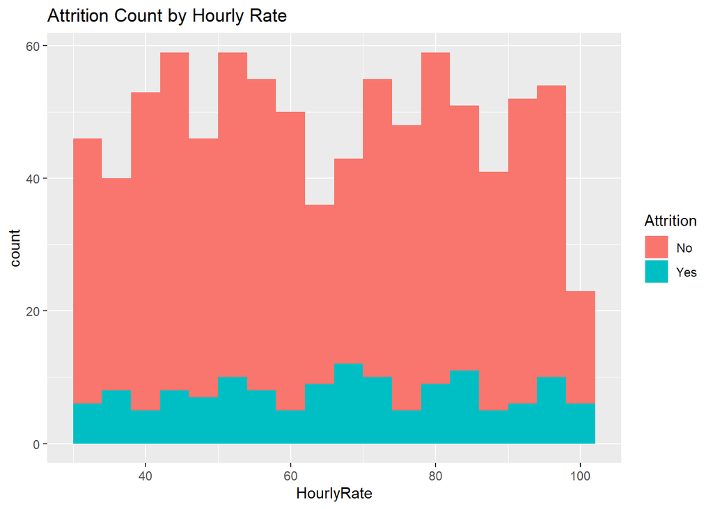

```r
employee %>% ggplot(aes(x = HourlyRate,fill=Attrition)) + geom_histogram(binwidth=4) + ggtitle("Attrition Count by Hourly Rate")
```

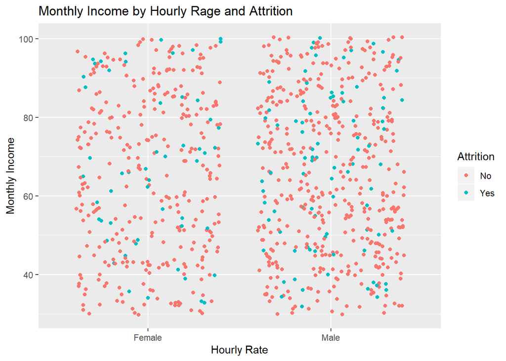

```r
employee %>% ggplot(aes(x = Gender,HourlyRate,col=Attrition)) + geom_point(pos='Jitter') + ggtitle("Monthly Income by Hourly Rage and Attrition") +
xlab ("Hourly Rate") +
ylab ("Monthly Income")
```

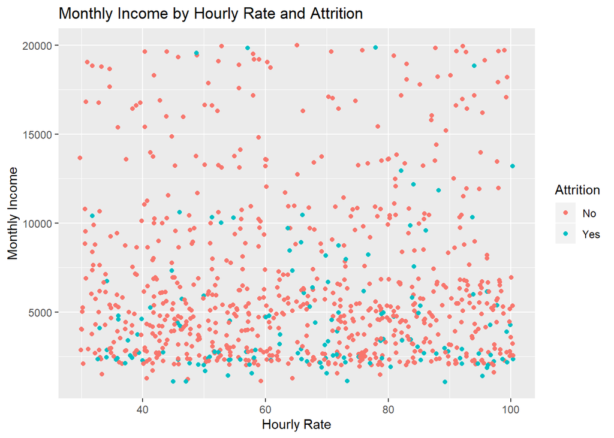

```r
###  Likely a billing rate

employee %>% ggplot(aes(x = HourlyRate,y=MonthlyIncome,col=Attrition)) + geom_point(pos='Jitter') + ggtitle("Monthly Income by Hourly Rate and Attrition") +
    xlab ("Hourly Rate") +
    ylab ("Monthly Income")
```

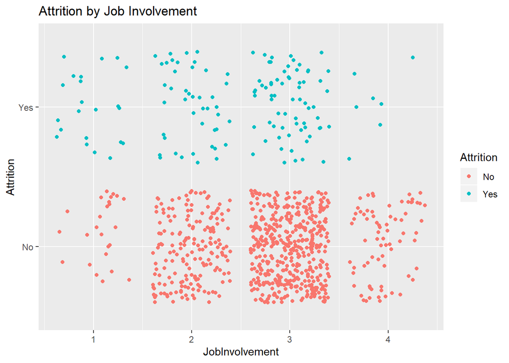

```r
### Categorical JobInvolvement
### Look at high job involvement

employee %>% ggplot(aes(x = JobInvolvement,y=Attrition,col=Attrition)) + geom_point(pos='Jitter') + ggtitle("Attrition by Job Involvement")
```

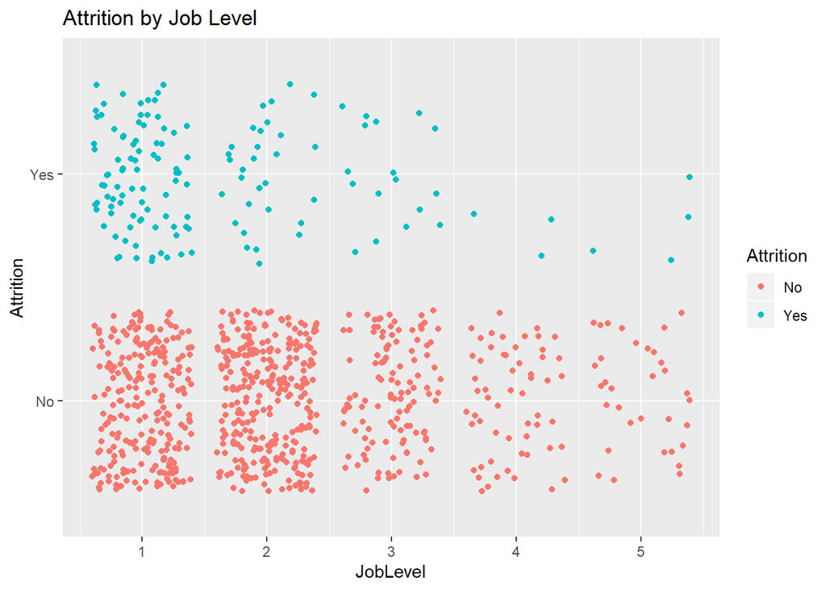

```r
### Categorical JobLevel
### Look at High Job Levels

employee %>% ggplot(aes(x = JobLevel,y=Attrition,col=Attrition)) + geom_point(pos='Jitter') + ggtitle("Attrition by Job Level")
```

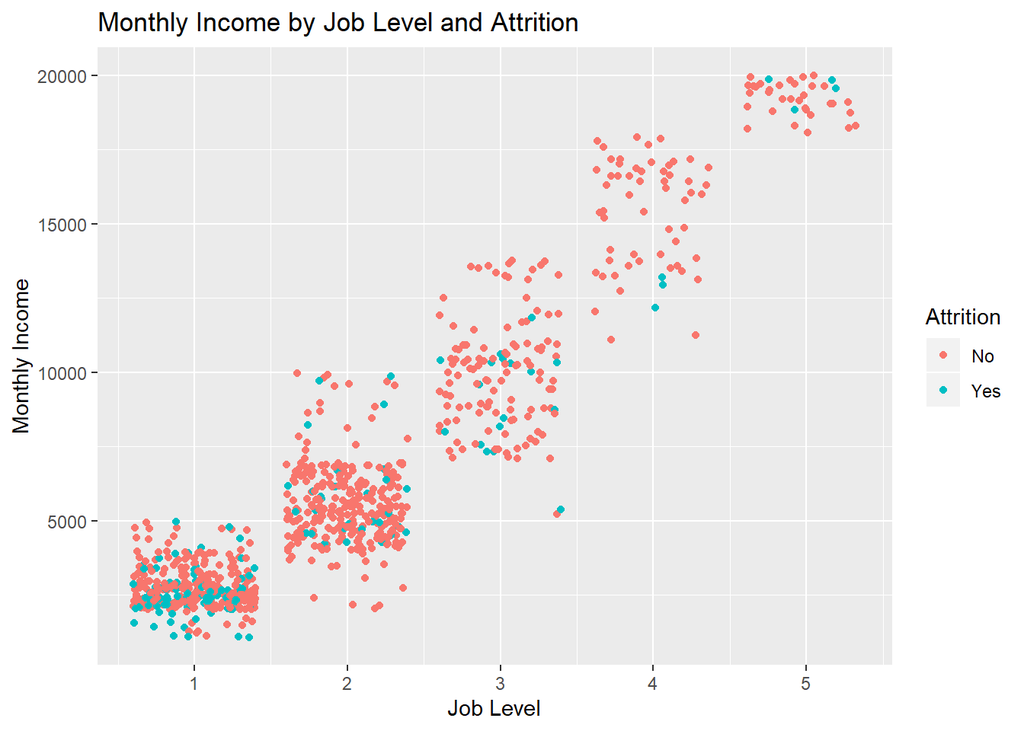

```r
employee %>% ggplot(aes(x = JobLevel,y=MonthlyIncome,col=Attrition)) + geom_point(pos='Jitter') + ggtitle("Monthly Income by Job Level and Attrition") +
    xlab ("Job Level") +
    ylab ("Monthly Income")
```

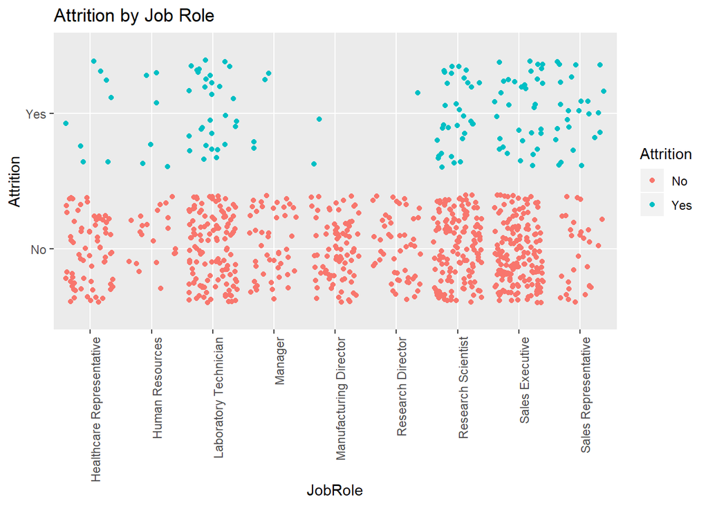

```r
### Categorical  JobRole
###  Look at Manager Manufacturing Director and Research Director

employee %>% ggplot(aes(x = JobRole,y=Attrition,col=Attrition)) + geom_point(pos='Jitter') + ggtitle("Attrition by Job Role") +
  theme(axis.text.x=element_text(angle=90, hjust=1))
```

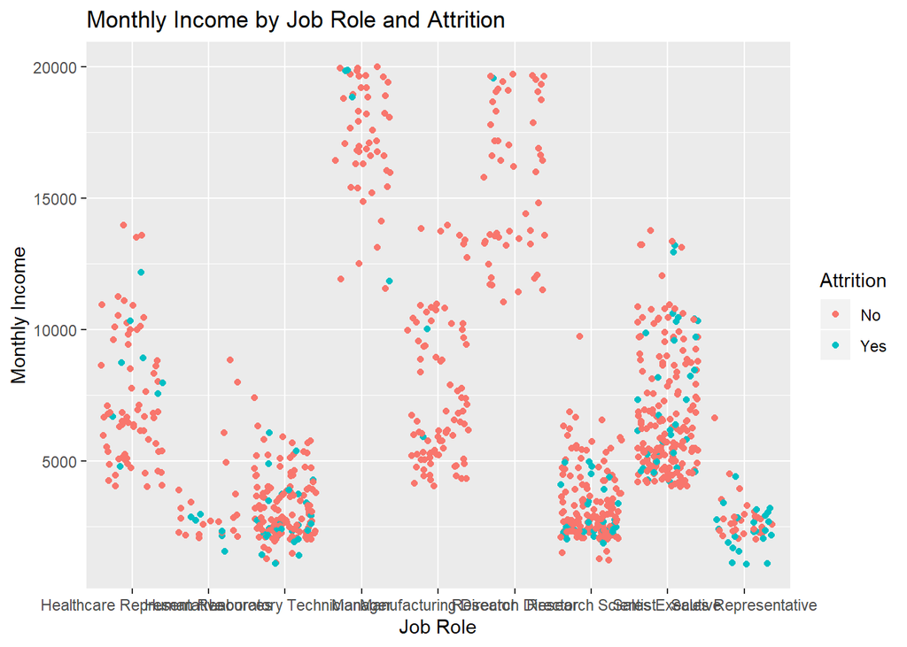

```r
employee %>% ggplot(aes(x = JobRole,y=MonthlyIncome,col=Attrition)) + geom_point(pos='Jitter') + ggtitle("Monthly Income by Job Role and Attrition") +
    xlab ("Job Role") +
    ylab ("Monthly Income")
```

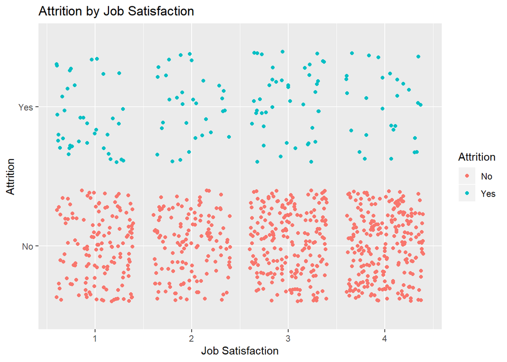

```r
### Categorical JobSatisfaction

employee %>% ggplot(aes(x = JobSatisfaction,y=Attrition,col=Attrition)) + geom_point(pos='Jitter') + ggtitle("Attrition by Job Satisfaction") +
xlab ("Job Satisfaction")
```

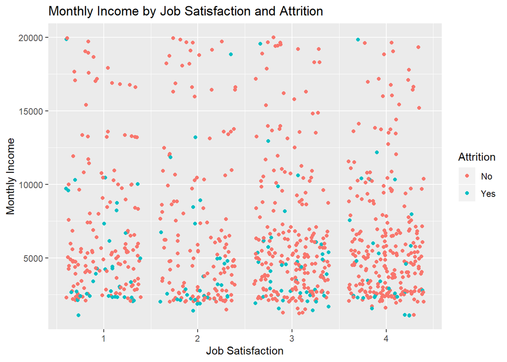

```r
employee %>% ggplot(aes(x = JobSatisfaction,y=MonthlyIncome,col=Attrition)) + geom_point(pos='Jitter') + ggtitle("Monthly Income by Job Satisfaction and Attrition") +
    xlab ("Job Satisfaction") +
    ylab ("Monthly Income")
```

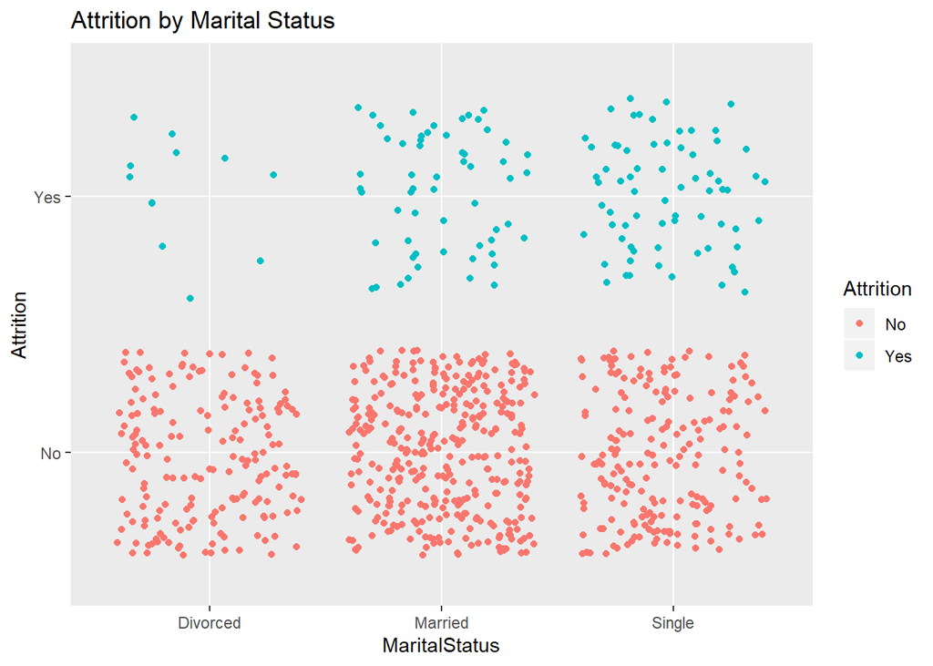

```r
### Categorical: MaritalStatus
###  Look at Divorced Women.  Divorced Men lower too

employee %>% ggplot(aes(x = MaritalStatus,y=Attrition,col=Attrition)) + geom_point(pos='Jitter') + ggtitle("Attrition by Marital Status")
```

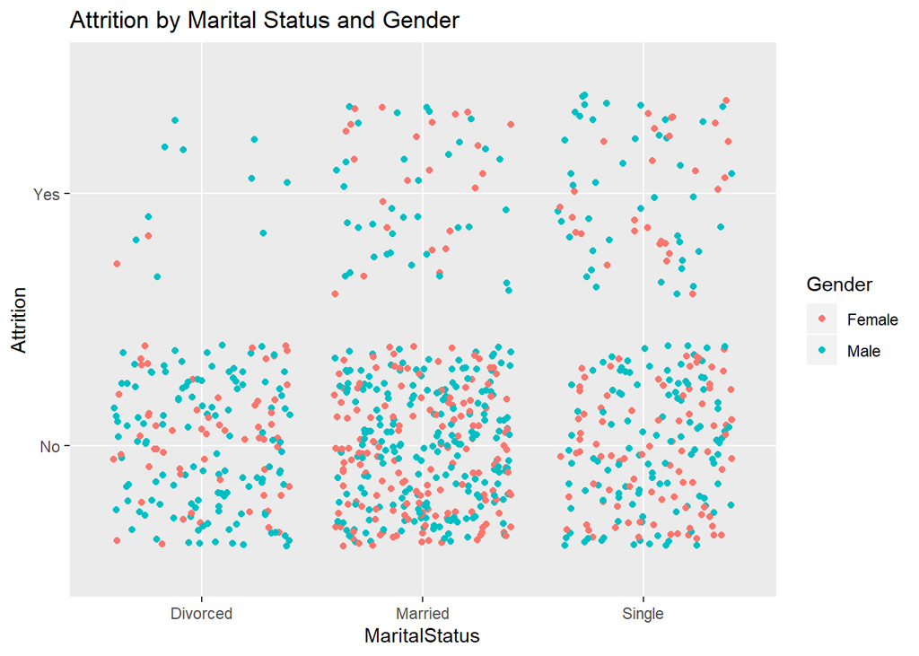

```r
employee %>% ggplot(aes(x = MaritalStatus,y=Attrition,col=Gender)) + geom_point(pos='Jitter') + ggtitle("Attrition by Marital Status and Gender")
```

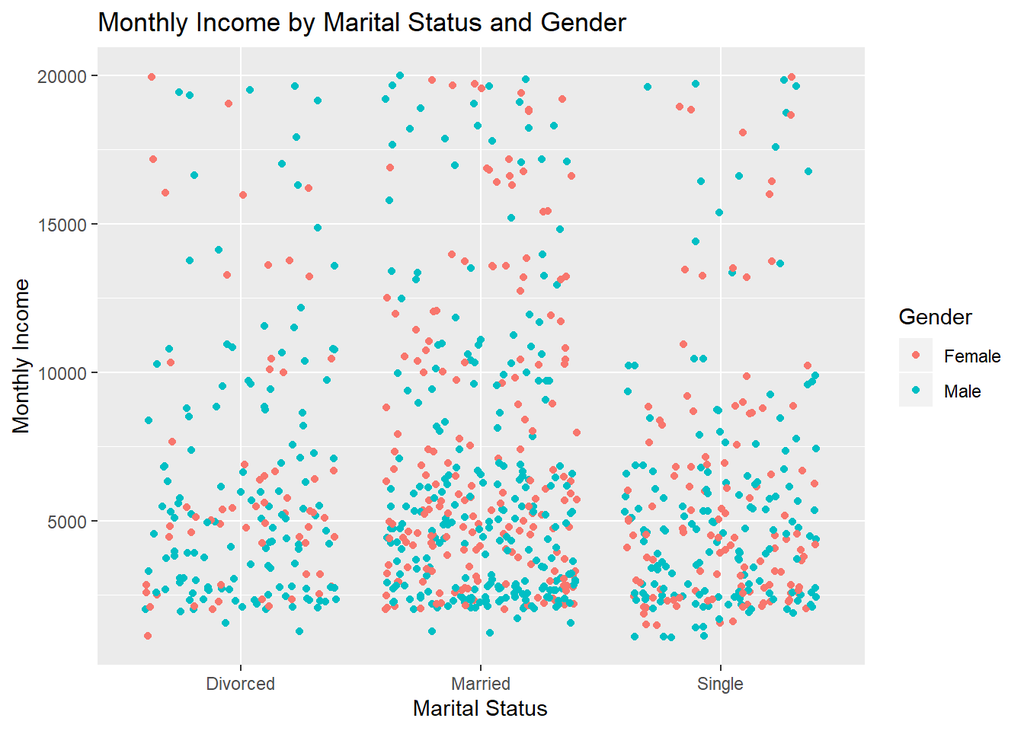

```r
employee %>% ggplot(aes(x = MaritalStatus,y=MonthlyIncome,col=Gender)) + geom_point(pos='Jitter') + ggtitle("Monthly Income by Marital Status and Gender") +
    xlab ("Marital Status") +
    ylab ("Monthly Income")
```